# EDA Notebook Analysis

2025-07-17

### Heart Attack Exploratory Data Analysis

**Team Members**: Yumeng Tan, Sherelle Li, Rom Zuckerman

### I. Introduction

#### 1) Introducing the Dataset

For this project, we work with data from the **2015 Behavioral Risk Factor Surveillance System (BRFSS)** – a nationwide health survey run each year by the Centers for Disease Control and Prevention (CDC) in partnership with U.S. states and territories ([CDC](https://www.kaggle.com/datasets/cdc/behavioral-risk-factor-surveillance-system?select=2015.csv)). The survey is conducted through telephone interviews, both land-line and cellular, reaching adults aged 18 and older living in community settings.

The BRFSS is designed to monitor health-related risk behaviors, chronic conditions, and preventive care usage across the United States. In 2015, it collected responses from 441,456 individuals, covering all 50 states, the District of Columbia, Puerto Rico, and Guam. Its large, nationally representative sample offers a rich and reliable snapshot of health behaviors. With 330 variables, the dataset provides extensive opportunities for exploration and analysis.

Beyond its size, the 2015 BRFSS has methodological advantages. First, the dataset is weighted to reflect state-level populations, making it a trusted source for public health planning, policy-making, and resource allocation. Second, more recent surveys have gaps in state participation—for example, the 2023 BRFSS excludes large states such as Pennsylvania and Kentucky—potentially reducing the reliability of national estimates. By contrast, the 2015 BRFSS offers complete state coverage, making it one of the most representative and comprehensive datasets for studying the U.S. population.

#### 2) Research Interest

The original dataset contains 330 columns, making it difficult to track variables relevant to our research. Therefore, we subset the data to include only the variables necessary for our analysis.

Our primary outcome of interest is `Heart Attack`. This choice is intentional: heart attacks are acute, life-threatening events that affect an estimated 17.9 million people worldwide each year ([NIH](https://www.nhlbi.nih.gov/health/heart-attack)) and require immediate medical attention. Moreover, they can occur even in individuals without a prior diagnosis of coronary heart disease ([Cleveland Clinic](https://my.clevelandclinic.org/health/diseases/16818-heart-attack-myocardial-infarction)). Therefore, identifying predictors is critical for preventing heart attack, making this outcome central to our study.

Based on prior research, `Body Mass Index (BMI)` is a plausible predictor of heart attack risk and is selected as the main predictor in our model. Excess body fat has been linked to inflammation, insulin resistance, and arterial damage ([NIH](https://pmc.ncbi.nlm.nih.gov/articles/PMC8449192/). Moreover, BMI is the primary diagnostic metric for obesity – a condition affecting 41.9% of U.S. adults ([CDC](https://www.cdc.gov/obesity/adult-obesity-facts/index.html)). Given obesity’s widespread prevalence and its cardiovascular implications, examining the relationship between BMI and heart attack risk has significant public health relevance.

Because BMI’s effect on heart attack risk may be influenced by other factors, we also include four demographic variables – `Sex`, `Race`, `Age`, and `Income` – as covariates. These variables help control for potential confounding and allow us to assess interactions between BMI and demographic characteristics.

  Taken together, these variables give us a comprehensive prediction on heart attack risks. The next step in our exploration will be preparing and transforming the data so we can uncover these relationships in a clear, systematic way.

### II. Dataset Manipulation

#### 1) Loading dataset and packages

1. **Install and load packages**: We set up the environment and install the packages necessary for our data analysis below. In the code below, we load all the installed packages to make the functions within them available to use in our script.

```r
# Load libraries
library(ggplot2)
library(car)
library(carData)
library(ResourceSelection)
```

```
## ResourceSelection 0.3-6   2023-06-27
```

```r
library(pROC)
library(dplyr)
library(emmeans)
library(ggeffects)
```

2. **Loading Dataset**: We first load our original dataset **2015.csv** into R Studio as data frame **df**.

```r
#Load original dataset
df <- read.csv("~/Documents/GitHub/EDA_Project/data/2015.csv")
```

3. **Selecting relevant variables**: The original dataset, `df`, contains 330 variables. To create a more concise and analysis-ready dataset, we subset it to include only the variables required for our study. These include the response variable **heart attack** (`CVDINFR4`) and the predictors **sex** (`SEX`), **income level** (`INCOME2`), **race** (`X_RACEGR3`), **age** (`X_AGE80` for numeric; `X_AGEG5YR` for categorical), and **BMI** (`X_BMI5` for numeric; `X_BMI5CAT` for categorical). The subsetted dataset is stored as a new data frame, `df1`.

```r
#Select relevant predictors and dependent variable
df1 <- df[, c("CVDINFR4", "SEX", "INCOME2", "X_RACEGR3", "X_AGEG5YR", "X_AGE80", "X_BMI5",
              "X_BMI5CAT")]
```

#### 2) Factoring and Renaming Variables

After selecting the response variable and main predictors, we redefine our variables in three steps: **factor variables**, **rename variables**, and **detect NA values**.

– **Factor variables**: In the original dataset, all variables are coded as numbers, even when they represent categories. We convert these numeric codes to their corresponding categorical labels using the `factor()` function.

– **Rename variables**: For clarity, we store the factored variables under more descriptive names.

– **Detect NA values**: In the BRFSS dataset, missing values are encoded as specific numeric codes for each variable (as documented in the 2015 BRFSS codebook available on the CDC website). We identify these codes for each variable and recode them to `NA` using the `factor()` function.

**(a)** Response Variable – HeartAttack

```r
# Recode CVDINFR4
df1$CVDINFR4[df1$CVDINFR4 %in% c(7, 9)] <- NA
df1$HeartAttack <- factor(df1$CVDINFR4, levels = c(1, 2), labels = c("Yes", "No"))
```

**(b)** Main Predictor – Body Mass Index

Our main predictor, **Body Mass Index (BMI)**, is stored as `X_BMI5` in the original dataset and is a numeric variable, so no factor conversion is required. In this variable, a value of `9999` indicates “Don’t know/Refused/Missing,” which we recode as `NA`. We then store the cleaned values in a new variable, `BMI_Num`. Because BMI values in the original dataset are multiplied by 100, we divide them by 100 to obtain the actual BMI values.

```r
# Recode _BMI5
df1$`X_BMI5`[df1$`X_BMI5` == 9999] <- NA
names(df1)[names(df1) == "X_BMI5"] <- "BMI_Num"
df1$BMI_Num <- df1$BMI_Num / 100
```

While BMI as a numeric variable is used in the regression model, BMI as a categorical variable with four categories is used in the EDA analysis and bar graphs. In the original dataset, this variable is stored as `X_BMI5CAT` and contains four categories: `1 = Underweight`, `2 = Normal`, `3 = Overweight`, and `4 = Obese`. We convert the numeric codes to descriptive labels using the `factor()` function and store the relabeled variable in a new variable, `BMI_Cat`.

```r
# Recode _BMI5CAT
df1$BMI_Cat <- factor(df1$`X_BMI5CAT`, levels = 1:4,
                         labels = c("Underweight", "Normal", "Overweight", "Obese"))
```

**(c)** Demographic Predictor – Sex

The first demographic predictor, **Sex**, is stored as `SEX` in the original dataset and contains two categories: `1 = Male` and `2 = Female`.We convert the numeric codes to descriptive labels using the `factor()` function and store the relabeled variable in a new variable, `SEX`.

```r
# Recode SEX
df1$SEX <- factor(df1$SEX, levels = c(1, 2), labels = c("Male", "Female"))
```

**(d)** Demographic Predictor – Income

The second demographic predictor, **Income**, is stored as `INCOME2` in the original dataset and contains nine categories: `1 = <$10k`, `2 = $10–15k`, `3 = $15–20k`, `4 = $20–25k`, `5 = $25–35k`, `6 = $35–50k`, `7 = $50–75k`, `8 = ≥$75k`, and `77` or `99` = *Don’t know / Not sure / Missing*. We convert the numeric codes into descriptive labels using the `factor()` function and recode `77` and `99` as `NA`. The cleaned variable is stored as `INCOME`.

```r
# Recode INCOME2
df1$INCOME2[df1$INCOME2 %in% c(77, 99)] <- NA
df1$INCOME <- factor(df1$INCOME2, levels = c(1:8),
                      labels = c("<$10k", "$10-15k", "$15-20k", "$20-25k", "$25-35k",
                                 "$35-50k", "$50-75k", ">=75k"))
```

**(e)** Demographic Predictor – Race

The third demographic predictor, **Race**, is stored as `X_RACEGR3` in the original dataset and contains six categories: `1 = White`, `2 = Black`, `3 = Other`, `4 = Multiracial`, `5 = Hispanic`, and `9 = Don't know / Not sure / Missing`. We convert the numeric codes into descriptive labels using the `factor()` function and recode `9` as `NA`. The cleaned variable is stored as `RACE`.

```r
# Recode _RACEGR3 as factor with appropriate labels
df1$`X_RACEGR3`[df1$`X_RACEGR3` == 9] <- NA
df1$RACE <- factor(df1$`X_RACEGR3`,
                         levels = c(1:5),
                         labels = c("White", "Black", "Other",
                                    "Multiracial", "Hispanic"))
```

**(f)** Demographic Predictor – Age

The fourth demographic predictor, **Age**, is stored as `X_AGE80` in the original dataset and is a numeric discrete variable representing age in years (capped at 80). We store this variable as `AGE_Num` for clarity.

```r
# Recode _AGE80
names(df1)[names(df1) == "X_AGE80"] <- "AGE_Num"
```

While age as a numeric variable is used in the regression model, age as a categorical variable with 13 categories is used in the EDA analysis and bar graphs. In the original dataset, this variable is stored as `X_AGEG5YR` and contains 13 ordered categories. We convert the numeric codes into descriptive labels using the `factor()` function and store the relabeled variable as `AGE`.

```r
# Recode _AGEG5YR
df1$AGE <- factor(df1$`X_AGEG5YR`, levels = 1:13,
                         labels = c("18–24", "25–29", "30–34", "35–39", "40–44", "45–49",
                                    "50–54", "55–59", "60–64", "65–69", "70–74", "75–79", "80+"))
```

#### 3) Handling Missing Values

After renaming and factoring the relevant variables and defining `NA` values, the next step is to remove any rows with missing data. We use the `na.omit()` function to delete rows containing `NA` values from the dataset. The cleaned dataset is stored as `df_clean` and exported as a CSV file for future use with the `write.csv()` function.

```r
# Remove rows with any NA values
df_clean <- na.omit(df1)

#save cleaned files into csv
write.csv(df_clean, "~/Documents/GitHub/EDA_Project/data/cleaned_data.csv", row.names = FALSE)
```

#### 4) Importing Cleanded Dataset

The final cleanded dataset is imported into R for future analysis using read.csv(). The dataset is stored as a new data frame `df_clean`.

```r
df_clean <- read.csv("~/Documents/GitHub/EDA_Project/data/cleaned_data.csv")
```

### III. Data Visualization and Tendency Measurement

#### 1) Frequency Distribution of Heart Attack and Predictors

**Visualization**: After obtaining the cleaned dataset, we visualize the distribution of the response variable **HeartAttack** and the five predictors. We also measure the central tendency using the mode, median, or mean, depending on whether the variable is categorical, ordinal, or numeric. For distribution statistics, we first calculate the frequency of observations within each category using `table()`, then convert frequencies to proportions using `prop.table()`. For visualization, we create bar graphs showing the proportion of observations in each category using the `ggplot()` function.

**Define Mode Function for Central Tendency Measurement**:  
We define a custom function `get_mode()` to calculate the mode, which will be used later for central tendency measurement. The function takes a vector as input, generates a frequency table, and returns the value with the highest frequency.

```r
# Function to calculate mode
get_mode <- function(v) {
  tbl <- table(v)
  mode_val <- names(tbl)[which.max(tbl)]
  return(mode_val)
}
```

**(a)** Response Variable – HeartAttack

Distribution is calculated and visualized as described above. For central tendency measurement, we calculate mode of the variable since it is categorical.

```r
#table
table(df_clean$HeartAttack)
```

```
##
##     No    Yes
## 317125  19655
```

```r
prop.table(table(df_clean$HeartAttack))
```

```
##
##         No        Yes
## 0.94163846 0.05836154
```

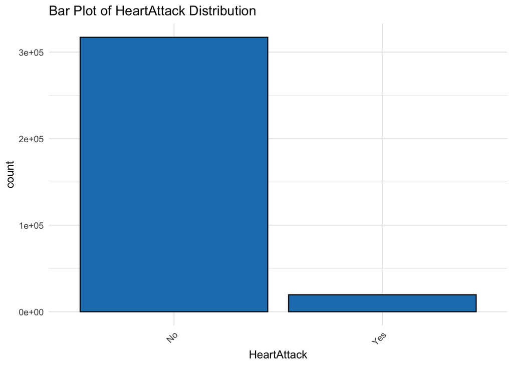

```r
#Bar graph
ggplot(df_clean, aes(x = HeartAttack)) +
  geom_bar(fill = "#1a80bb", color = "black") +
  ggtitle("Bar Plot of HeartAttack Distribution") +
  theme_minimal() +
  theme(axis.text.x = element_text(angle = 45, hjust = 1))
```

```r
#Central Tendency -- Mode
cat("Head_Attack\n")
```

```
## Head_Attack
```

```r
cat("Mode:", get_mode(df_clean$HeartAttack), "\n\n")
```

```
## Mode: No
```

**(b)** Predictor – BMI

For distribution statistics and visualization, we use the categorical version of BMI (`BMI_Cat`). When using the numeric version (`BMI_Num`), the proportion is calculated for each distinct numeric value, which can make the plot difficult to interpret and may not reveal meaningful variation. In contrast, the categorical version provides a clearer view of how the distribution varies across the main BMI categories.

For central tendency measurement, we use the numeric version (`BMI_Num`) to obtain more detailed statistics. Specifically, we calculate the **mode**, **median**, and **mean** of BMI to better understand its central distribution.

```r
#table
table(df_clean$BMI_Cat)
```

```
##
##      Normal       Obese  Overweight Underweight
##      106101      102531      123139        5009
```

```r
prop.table(table(df_clean$BMI_Cat))
```

```
##
##      Normal       Obese  Overweight Underweight
##  0.31504543  0.30444504  0.36563632  0.01487321
```

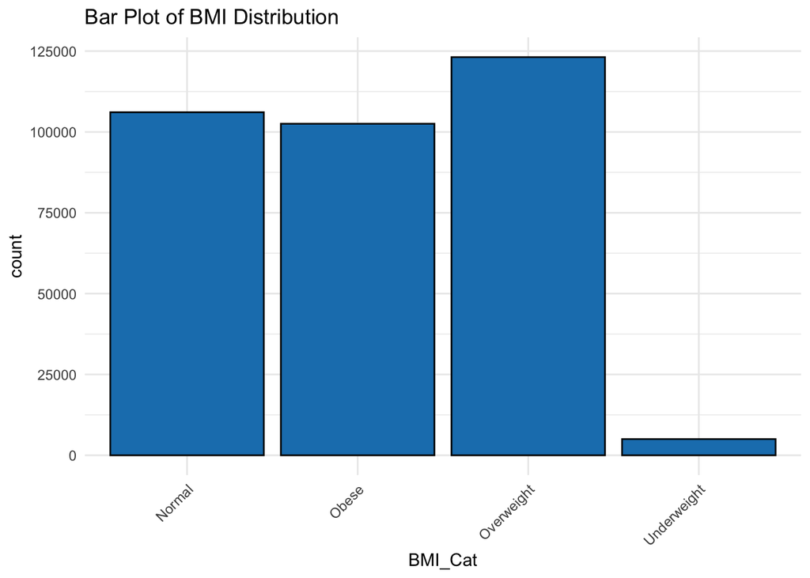

```r
#Bar graph
ggplot(df_clean, aes(x = BMI_Cat)) +
  geom_bar(fill = "#1a80bb", color = "black") +
  ggtitle("Bar Plot of BMI Distribution") +
  theme_minimal() +
  theme(axis.text.x = element_text(angle = 45, hjust = 1))
```

```r
#Central Tendency -- Mode and Median and Mean
cat("BMI_Num\n")
```

```
## BMI_Num
```

```r
cat("Mode:", get_mode(df_clean$BMI_Num), "\n")
```

```
## Mode: 26.63
```

```r
cat("Median:", median(df_clean$BMI_Num, na.rm = TRUE), "\n")
```

```
## Median: 27.12
```

```r
cat("Mean:", mean(df_clean$BMI_Num, na.rm = TRUE), "\n\n")
```

```
## Mean: 28.18848
```

**(c)** Predictor – Sex

Distribution is calculated and visualized as described above. For central tendency measurement, we calculate mode of the variable since it is categorical.

```r
#table
table(df_clean$SEX)
```

```
##
## Female   Male
## 184139 152641
```

```r
prop.table(table(df_clean$SEX))
```

```
##
##    Female      Male
## 0.5467635 0.4532365
```

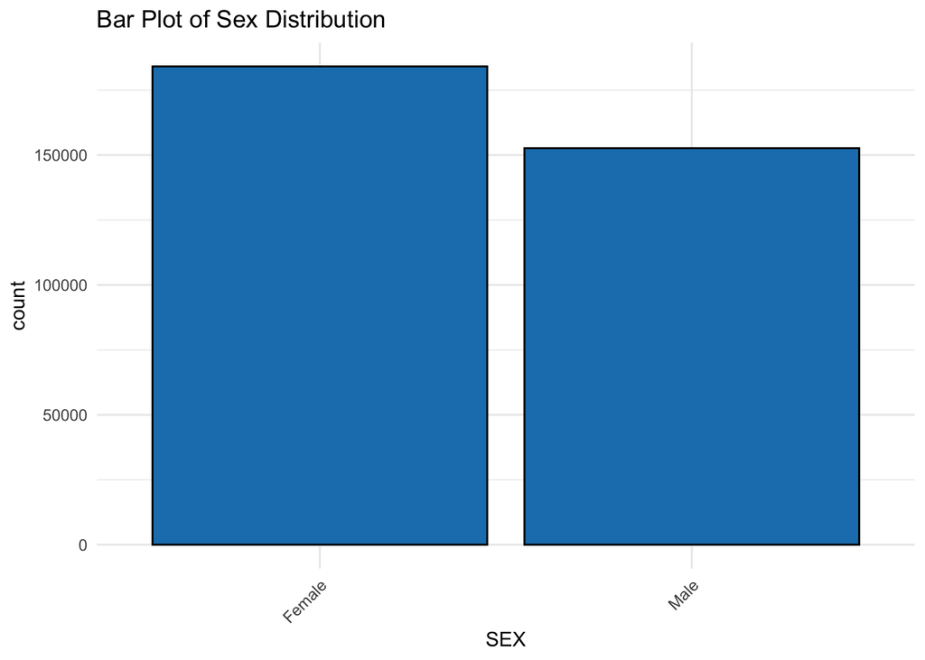

```r
#Bar graph
ggplot(df_clean, aes(x = SEX)) +
  geom_bar(fill = "#1a80bb", color = "black") +
  ggtitle("Bar Plot of Sex Distribution") +
  theme_minimal() +
  theme(axis.text.x = element_text(angle = 45, hjust = 1))
```

```r
#Central Tendency -- Mode
cat("Sex\n")
```

```
## Sex
```

```r
cat("Mode:", get_mode(df_clean$SEX), "\n\n")
```

```
## Mode: Female
```

**(d)** Predictor – Income

Distribution is calculated and visualized as described above. For central tendency measurement, we calculate mode of the variable since it is categorical.

```r
#table
table(df_clean$INCOME)
```

```
##
##   <$10k   >=75k $10-15k $15-20k $20-25k $25-35k $35-50k $50-75k
##   16517  108690   17963   24506   29699   36376   48500   54529
```

```r
prop.table(table(df_clean$INCOME))
```

```
##
##      <$10k      >=75k    $10-15k    $15-20k    $20-25k    $25-35k    $35-50k
## 0.04904389 0.32273294 0.05333749 0.07276560 0.08818517 0.10801116 0.14401093
##    $50-75k
## 0.16191282
```

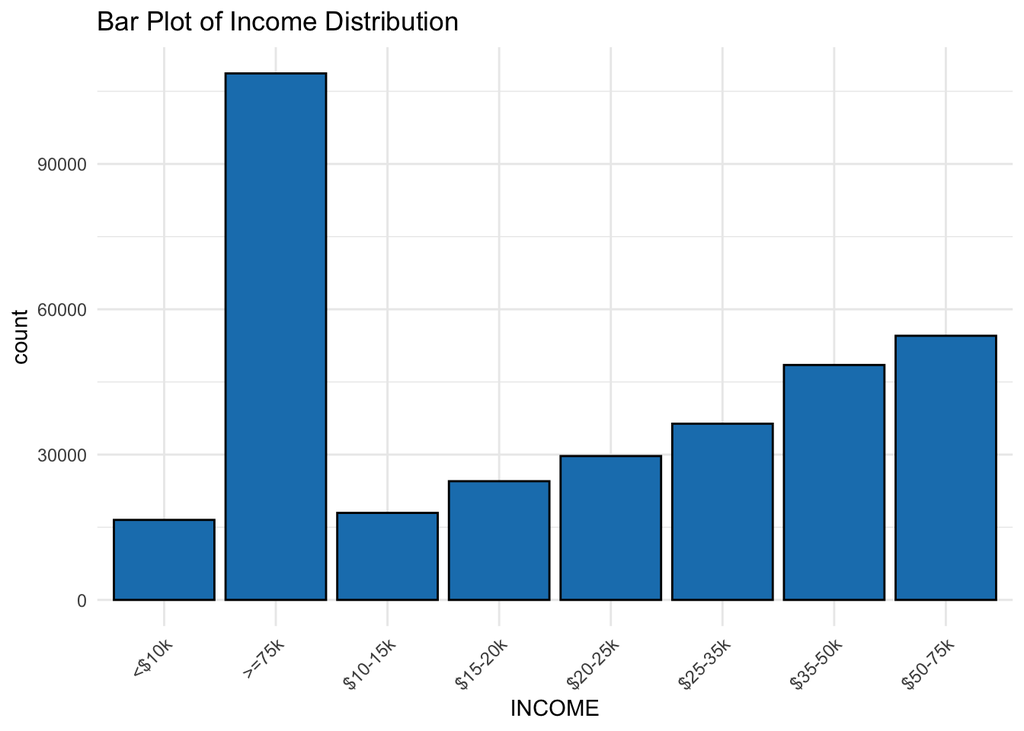

```r
#Bar graph
ggplot(df_clean, aes(x = INCOME)) +
  geom_bar(fill = "#1a80bb", color = "black") +
  ggtitle("Bar Plot of Income Distribution") +
  theme_minimal() +
  theme(axis.text.x = element_text(angle = 45, hjust = 1))
```

```r
#Central Tendency -- Mode
cat("Income\n")
```

```
## Income
```

```r
cat("Mode:", get_mode(df_clean$INCOME), "\n")
```

```
## Mode: >=75k
```

**Interpretation**: The Income distribution is skewed to the left, with most subjects (or the mode) belonging to the income group of over 75 thousand dollars in income per year. This means that we have a lot more subjects that had a higher income value than other income groups.

**(e)** Predictor – Race

Distribution is calculated and visualized as described above. For central tendency measurement, we calculate mode of the variable since it is categorical.

```r
#table
table(df_clean$RACE)
```

```
##
##       Black    Hispanic Multiracial       Other       White
##       26117       26684        6531       15039      262409
```

```r
prop.table(table(df_clean$RACE))
```

```
##
##       Black    Hispanic Multiracial       Other       White
##  0.07754914  0.07923273  0.01939248  0.04465526  0.77917038
```

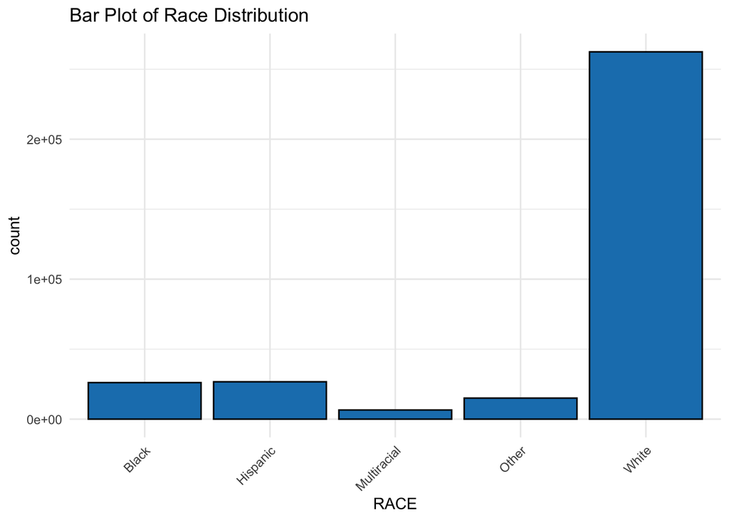

```r
#Bar graph
ggplot(df_clean, aes(x = RACE)) +
  geom_bar(fill = "#1a80bb", color = "black") +
  ggtitle("Bar Plot of Race Distribution") +
  theme_minimal() +
  theme(axis.text.x = element_text(angle = 45, hjust = 1))
```

```r
#Central Tendency -- Mode
cat("Race\n")
```

```
## Race
```

```r
cat("Mode:", get_mode(df_clean$RACE), "\n\n")
```

```
## Mode: White
```

**(f)** Predictor – Age

For distribution statistics and visualization, we use the categorical version of Age (`AGE`). When using the numeric version (`AGE_Num`), the proportion is calculated for each distinct numeric value, which can make the plot difficult to interpret and may not reveal meaningful variation. In contrast, the categorical version provides a clearer view of how the distribution varies across the main age groups.

For central tendency measurement, we use the numeric version (`AGE_Num`) to obtain more detailed statistics. Specifically, we calculate the **mode**, **median**, and **mean** of Age to better understand its central distribution.

```r
#table
table(df_clean$AGE)
```

```
##
## 18–24 25–29 30–34 35–39 40–44 45–49 50–54 55–59 60–64 65–69 70–74 75–79   80+
## 16068 15414 18352 20082 21460 24997 32426 37106 39392 38019 28568 20353 24543
```

```r
prop.table(table(df_clean$AGE))
```

```
##
##      18–24      25–29      30–34      35–39      40–44      45–49      50–54
## 0.04771067 0.04576875 0.05449255 0.05962943 0.06372112 0.07422353 0.09628244
##      55–59      60–64      65–69      70–74      75–79        80+
## 0.11017875 0.11696657 0.11288972 0.08482689 0.06043411 0.07287547
```

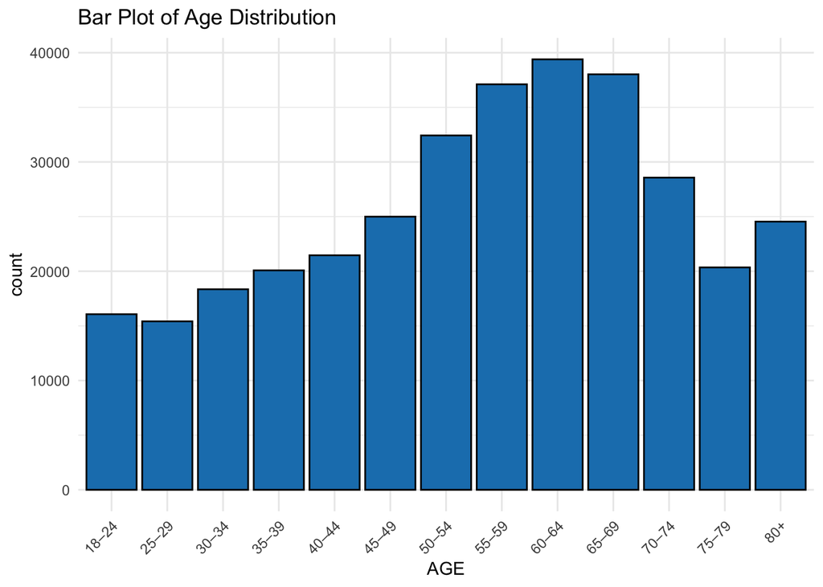

```r
#Bar graph
ggplot(df_clean, aes(x = AGE)) +
  geom_bar(fill = "#1a80bb", color = "black") +
  ggtitle("Bar Plot of Age Distribution") +
  theme_minimal() +
  theme(axis.text.x = element_text(angle = 45, hjust = 1))
```

```r
#Central Tendency -- Mode and Median
cat("AGE_Num\n")
```

```
## AGE_Num
```

```r
cat("Mode:", get_mode(df_clean$AGE_Num), "\n")
```

```
## Mode: 80
```

```r
cat("Median:", median(df_clean$AGE_Num, na.rm = TRUE), "\n")
```

```
## Median: 57
```

```r
cat("Mean:", mean(df_clean$AGE_Num, na.rm = TRUE), "\n\n")
```

```
## Mean: 55.04132
```

**Interpretation**: This Age distribution is skewed to the left, with more participants at older ages, and it has a median of 55-59. This makes our results much more comprehensive for ages across our range.

#### 2) Correlation Analysis

Moving beyond visualizing distribution, for each predictor, we examine how the proportion of participants with **HeartAttack** varies across different categorical levels. This analysis provides an initial insight into the potential significance of each predictor and hints at the possible sign of the coefficients in a regression analysis on **HeartAttack**.

For distribution statistics, we calculate the proportion of individuals with heart attack within each category of the predictor using the `prop.table()` function. For visualization, we use bar graphs created with `ggplot()` to display the proportion of participants with heart attack in each category.

We first define the main theme color for the future bar graphs

```r
custom_colors <- c("No" = "#1a80bb", "Yes" = "#f2c45f")
```

**(a)** Heart Attack vs. BMI Categories

For distribution statistics and visualization of **HeartAttack** across BMI levels, we use the categorical version of BMI (`BMI_Cat`). When using the numeric version (`BMI_Num`), the proportion is calculated for each distinct numeric value, which can make the results difficult to interpret and may not reveal meaningful variation. In contrast, the categorical version provides a clearer view of how the distribution of heart attack cases varies across the main BMI categories.

```r
#Table
prop.table(table(df_clean$HeartAttack, df_clean$BMI_Cat), margin = 2)
```

```
##
##           Normal      Obese Overweight Underweight
##   No  0.95678646 0.92796325 0.94033572  0.93272110
##   Yes 0.04321354 0.07203675 0.05966428  0.06727890
```

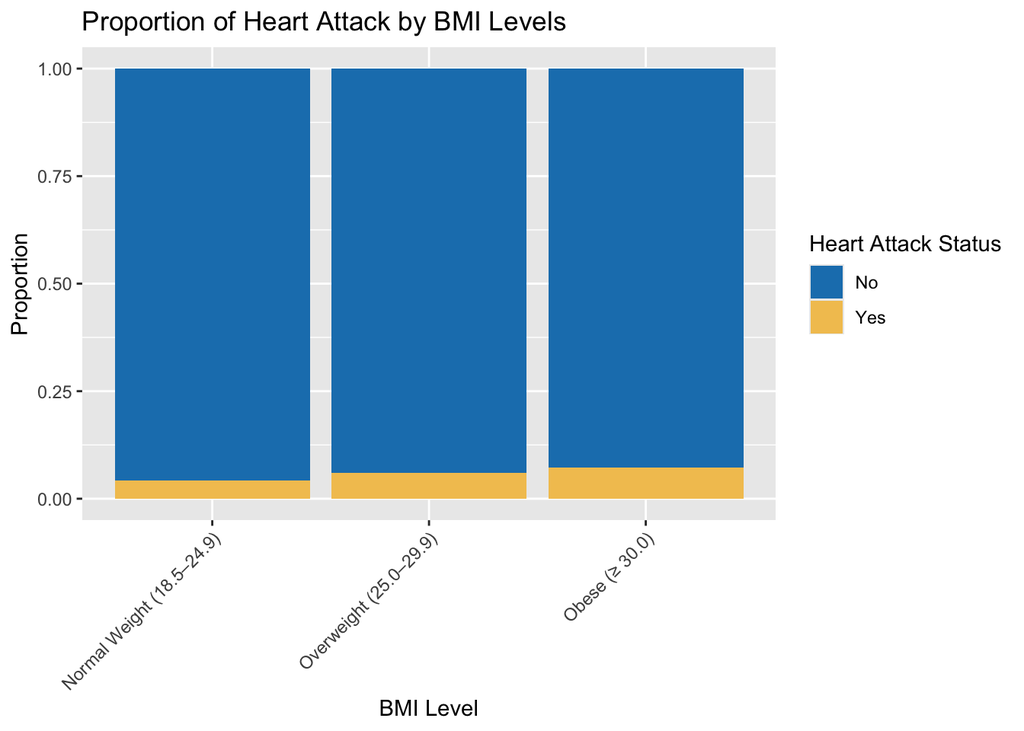

```r
#Bar graph
ggplot(df_clean, aes(x = BMI_Cat, fill = HeartAttack)) +
  geom_bar(position = "fill") +
  ylab("Proportion") +
  xlab("BMI Level") +
  labs(fill = "Heart Attack Status") +
  scale_x_discrete(
    limits = c("Normal", "Overweight", "Obese"),
    labels = c(
      "Normal"      = "Normal Weight (18.5–24.9)",
      "Obese"       = "Obese (≥ 30.0)",
      "Overweight"  = "Overweight (25.0–29.9)"
    ),
    drop = TRUE
  ) +
  ggtitle("Proportion of Heart Attack by BMI Levels") +
  scale_fill_manual(values = custom_colors) +
  theme(axis.text.x = element_text(angle = 45, hjust = 1))
```

**(b)** Heart Attack vs. Sex

Distribution of heart attack across sex groups is calculated and visualized as described above.

```r
#Table
prop.table(table(df_clean$HeartAttack, df_clean$SEX), margin = 2)
```

```
##
##           Female       Male
##   No  0.95763526 0.92234066
##   Yes 0.04236474 0.07765934
```

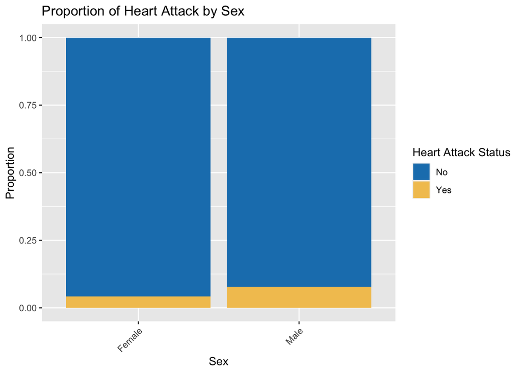

```r
#Bar graph
ggplot(df_clean, aes(x = SEX, fill = HeartAttack)) +
  geom_bar(position = "fill") +
  ylab("Proportion") +
  xlab("Sex") +
  labs(fill = "Heart Attack Status") +
  ggtitle("Proportion of Heart Attack by Sex") +
  scale_fill_manual(values = custom_colors) +
  theme(axis.text.x = element_text(angle = 45, hjust = 1))
```

**(c)** Heart Attack vs. Income Level

Distribution of heart attack across income levels is calculated and visualized as described above.

```r
#Table
prop.table(table(df_clean$HeartAttack, df_clean$INCOME), margin = 2)
```

```
##
##            <$10k      >=75k    $10-15k    $15-20k    $20-25k    $25-35k
##   No  0.90549131 0.97169933 0.88459611 0.90169754 0.91663019 0.92659996
##   Yes 0.09450869 0.02830067 0.11540389 0.09830246 0.08336981 0.07340004
##
##          $35-50k    $50-75k
##   No  0.94018557 0.95435456
##   Yes 0.05981443 0.04564544
```

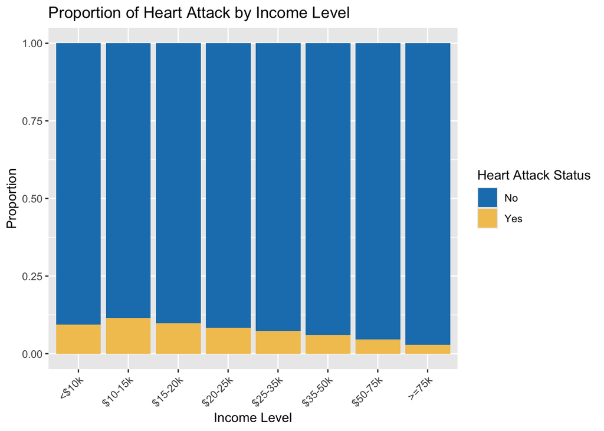

```r
#Bar graph
ggplot(df_clean, aes(x = INCOME, fill = HeartAttack)) +
  geom_bar(position = "fill") +
  ylab("Proportion") +
  xlab("Income Level") +
  labs(fill = "Heart Attack Status") +
  ggtitle("Proportion of Heart Attack by Income Level") +
  scale_fill_manual(values = custom_colors) +
  scale_x_discrete(limits = c("<$10k", "$10-15k", "$15-20k", "$20-25k", "$25-35k", "$35-50k", "$50-75k", ">=75k")) +
  theme(axis.text.x = element_text(angle = 45, hjust = 1))
```

**(d)** Heart Attack vs. Race

Distribution of heart attack across race groups is calculated and visualized as described above.

```r
#Table
prop.table(table(df_clean$HeartAttack, df_clean$RACE), margin = 2)
```

```
##
##            Black   Hispanic Multiracial      Other      White
##   No  0.94562928 0.96057563  0.93186342 0.95072811 0.93903791
##   Yes 0.05437072 0.03942437  0.06813658 0.04927189 0.06096209
```

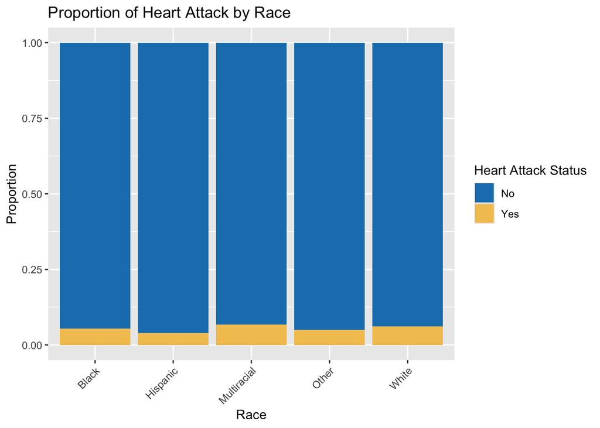

```r
#Bar graph
ggplot(df_clean, aes(x = RACE, fill = HeartAttack)) +
  geom_bar(position = "fill") +
  ylab("Proportion") +
  xlab("Race") +
  labs(fill = "Heart Attack Status") +
  ggtitle("Proportion of Heart Attack by Race") +
  scale_fill_manual(values = custom_colors) +
  theme(axis.text.x = element_text(angle = 45, hjust = 1))
```

**(e)** Heart Attack vs. Age

For distribution statistics and visualization of **HeartAttack** across age groups, we use the categorical version of Age (`AGE`). When using the numeric version (`AGE_Num`), the proportion is calculated for each distinct numeric value, which can make the results difficult to interpret and may not reveal meaningful variation. In contrast, the categorical version provides a clearer view of how the distribution of heart attack cases varies across the main age categories.

```r
#Table
prop.table(table(df_clean$HeartAttack, df_clean$AGE), margin = 2)
```

```
##
##             18–24       25–29       30–34       35–39       40–44       45–49
##   No  0.997137167 0.995847930 0.993297733 0.990439199 0.984389562 0.975197024
##   Yes 0.002862833 0.004152070 0.006702267 0.009560801 0.015610438 0.024802976
##
##             50–54       55–59       60–64       65–69       70–74       75–79
##   No  0.963177697 0.950061985 0.933438262 0.914963571 0.891591991 0.876430993
##   Yes 0.036822303 0.049938015 0.066561738 0.085036429 0.108408009 0.123569007
##
##               80+
##   No  0.846758750
##   Yes 0.153241250
```

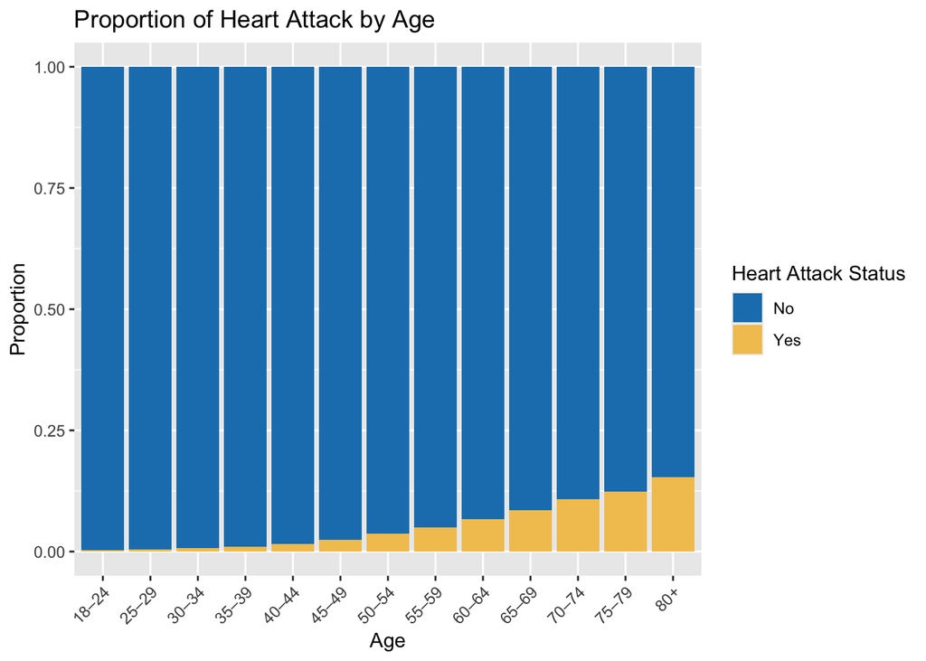

```r
#Bar graph
ggplot(df_clean, aes(x = AGE, fill = HeartAttack)) +
  geom_bar(position = "fill") +
  ylab("Proportion") +
  xlab("Age") +
  labs(fill = "Heart Attack Status") +
  ggtitle("Proportion of Heart Attack by Age") +
  scale_fill_manual(values = custom_colors) +
  theme(axis.text.x = element_text(angle = 45, hjust = 1))
```

**(f)** Conclusion

Based on the correlation analysis, a positive association is observed between the main predictor **BMI** and heart attack risk. When BMI increases from the normal group (18.5–24.9) to the obese group (≥30.0), the percentage of individuals with heart attack rises from **4.3%** to **7.2%**, suggesting BMI is a potential predictor of heart attack risk.

Beyond BMI, the proportion of individuals with heart attack also varies across all demographic variables, indicating that these variables may act as confounders and should be controlled in the regression model.

- **Sex**: The proportion of heart attack cases is higher among males (**7.8%**) than females (**4.2%**), suggesting higher risk for males.
- **Age**: There is a strong positive correlation between age and heart attack proportion—risk increases with age.
- **Income**: The proportion decreases as income level increases, suggesting a potential negative correlation between income and heart attack risk.
- **Race**: The multiracial group has the highest proportion of individuals with heart attack, while the Hispanic group has the lowest proportion.

### IV. Next Step

Our preliminary analysis revealed clear differences in heart attack prevalence across `BMI` levels and demographic groups. People with higher `BMI` were more likely to report having had a heart attack, and similar patterns appeared for older `AGE`, lower `INCOME`, being male (`SEX`), and certain `RACE` groups. These patterns suggest that `BMI` could be an important predictor of heart attack risk. However, factors like age or income might also be linked to both `BMI` and heart attack risk at the same time – meaning they could influence the relationship we see between `BMI` and heart attacks. To give a hypothetical example, being male could be associated with a higher chance of arterial stiffening and a tendency to have lower `BMI` on average. If we didn’t account for `SEX`, we might mistakenly think `BMI` has a weaker or stronger effect than it really does. Controlling for such confounding variables helps us isolate the effect of `BMI` from the effects of these other factors.

Building on these findings, the main objective of this project is to model the odds of `HeartAttack` with `BMI` as the primary predictor, while controlling for potential confounders – `SEX`, `INCOME`, `AGE`, and `RACE` – identified from the EDA. This approach allows us to quantify the association between `BMI` and `HeartAttack` risk while accounting for demographic differences observed in the descriptive analysis.

The final extended model will be validated for robustness: multicollinearity will be checked using Variance Inflation Factor (VIF) to see if predictors are too strongly related to each other, which can distort results. Model performance will be evaluated using the error rate test.